# Introduction to pRecipe

## Processing

Once we have downloaded our database, we can start processing the data with:

- `crop_data` to crop the data using a shapefile.
- `fldmean` to generate a time series by taking the area weighted average over each timestep.
- `remap` to go from the native resolution (0.25°) to coarser ones (e.g., 0.5°, 1°, 1.5°, …).
- `subset_data` to subset the data in time and/or space.
- `yearstat` to aggregate the data from monthly into annual.

### Subset

To subset our data to a desired region and period of interest, we use the `subset_data` function, which has three arguments *x*, *box*, and *yrs*.

- *x* Raster* object or a data.table or a filename (character).
- *box* is the bounding box of the region of interest with the coordinates in degrees in the form (xmin, xmax, ymin, ymax).
- *yrs* is the period of interest with years in the form (start_year, end_year).

Let’s subset the GPM-IMERGM data set over South America (-96, -30, -56, 24) for the 2001-2015 period, and inspect its content with `infoNC`:

```r
gpm_subset <- subset_data(gpm_global, box = c(-96, -30, -56, 24), yrs = c(2001, 2015))
infoNC(gpm_subset)
```

[output not shown]

### Crop

To further crop our data to a desired polygon other than a rectangle, we use the `crop_data` function, which has two arguments *x*, and *y*.

- *x* Raster* object or a data.table or a *.nc filename (character).
- *y* is a “.shp” filename (character).

Let’s crop our GPM-IMERG subset to cover only Bolivia with the respective [shape file](https://geodata.ucdavis.edu/gadm/gadm4.1/shp/gadm41_BOL_shp.zip), and inspect its content with `infoNC`:

```r
gpm_bol <- crop_data(gpm_subset, "gadm41_BOL_0.shp")
infoNC(gpm_bol)
```

```
[1] "class      : RasterBrick "
[2] "dimensions : 54, 50, 2700, 180  (nrow, ncol, ncell, nlayers)"
[3] "resolution : 0.25, 0.25  (x, y)"
[4] "extent     : -69.75, -57.25, -23, -9.5  (xmin, xmax, ymin, ymax)"
[5] "crs        : +proj=longlat +datum=WGS84 +no_defs "
[6] "source     : memory"
[7] "names      :  X2001.01.01,  X2001.02.01,  X2001.03.01,  X2001.04.01,  X2001.05.01,  X2001.06.01,  X2001.07.01,  X2001.08.01,  X2001.09.01,  X2001.10.01,  X2001.11.01,  X2001.12.01,  X2002.01.01,  X2002.02.01,  X2002.03.01, ... "
[8] "min values : 4.359420e+01, 5.965404e+01, 9.195424e+00, 2.650523e+00, 4.473422e-01, 4.649702e-03, 3.581941e-04, 1.511060e-02, 3.136731e-01, 5.168897e-01, 3.443884e-01, 1.019173e+01, 3.299495e+00, 2.491986e+01, 1.160967e+01, ... "
[9] "max values :    613.21777,    530.11438,    497.65503,    371.26581,    216.29959,    136.70122,    209.37540,    124.56583,    166.48785,    313.69836,    472.29553,    487.41364,    613.77014,    673.70099,    549.12671, ... "
[10] "time       : 2001-01-01, 2015-12-01 (min, max)"
```

### Generate Time series

To make a time series out of our data, we use the `fldmean` function, which has one argument *x*.

- *x* Raster* object or a data.table or a *.nc filename (character).

Let’s generate the time series for our three different GPM-IMERGM data sets (Global, South America, and Bolivia), and inspect its first 12 rows:

```r
gpm_global_ts <- fldmean(gpm_global)
head(gpm_global_ts, 12)
```

```
          date     value
        <Date>     <num>
 1: 2000-06-01  93.64844
 2: 2000-07-01  96.05852
 3: 2000-08-01  94.18216
 4: 2000-09-01  90.43190
 5: 2000-10-01  93.91238
 6: 2000-11-01  93.61439
 7: 2000-12-01  96.70333
 8: 2001-01-01  94.67989
 9: 2001-02-01  86.00950
10: 2001-03-01  96.15177
11: 2001-04-01  97.05069
12: 2001-05-01 100.53676
```

```r
gpm_subset_ts <- fldmean(gpm_subset)
head(gpm_subset_ts, 12)
```

```
          date     value
        <Date>     <num>
 1: 2001-01-01 106.52438
 2: 2001-02-01  89.98158
 3: 2001-03-01 113.35350
 4: 2001-04-01 107.26019
 5: 2001-05-01 123.50707
 6: 2001-06-01  94.20347
 7: 2001-07-01 102.07352
 8: 2001-08-01  94.62878
 9: 2001-09-01  96.31932
10: 2001-10-01 112.90529
11: 2001-11-01 102.68565
12: 2001-12-01 113.49551
```

```r
gpm_bol_ts <- fldmean(gpm_bol)
head(gpm_bol_ts, 12)
```

```
          date     value
        <Date>     <num>
 1: 2001-01-01 233.87604
 2: 2001-02-01 183.34294
 3: 2001-03-01 165.97789
 4: 2001-04-01  85.02165
 5: 2001-05-01  63.68961
 6: 2001-06-01  24.68989
 7: 2001-07-01  31.89638
 8: 2001-08-01  17.94735
 9: 2001-09-01  55.87102
10: 2001-10-01 103.33750
11: 2001-11-01 163.95180
12: 2001-12-01 156.72036
```

## Visualize

Either after we have processed our data as required or right after downloaded, we have different options to visualize our data:

- `plot_box` to see a seasonal boxplot.
- `plot_density` to see the empirical density of monthly precipitation.
- `plot_heatmap` to see a heatmap of all monthly values.
- `plot_line` to see the average time series.
- `plot_map` to see the Cartesian lon-lat map of the first raster layer.
- `plot_summary` to see line, heatmap, box, and density plot together in a single plot.
- `plot_taylor` to see a Taylor Diagram (requires a referential data set).

Let’s plot our three different GPM-IMERGM data sets (Global, South America, and Bolivia)

### Maps

To see a map of any data set raw or processed, we use `plot_map`.

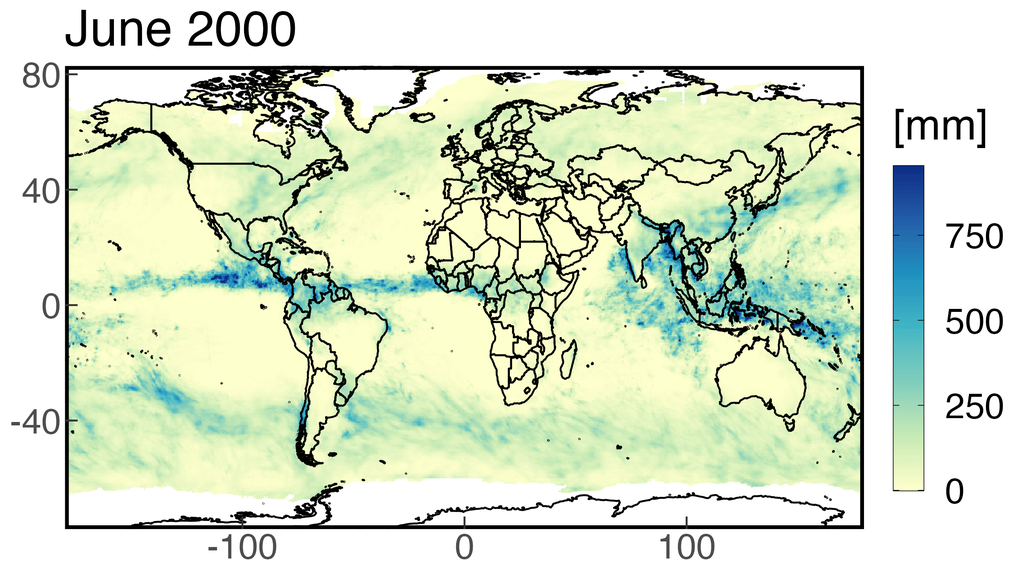

```r
plot_map(gpm_global)
```

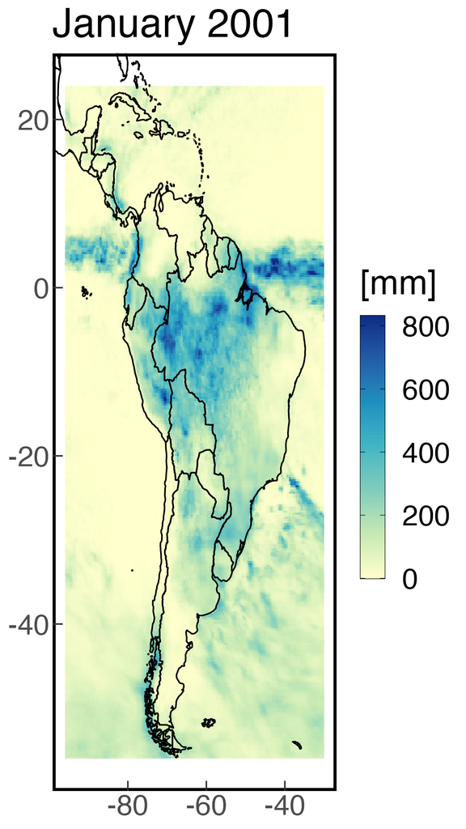

```r
plot_map(gpm_subset)
```

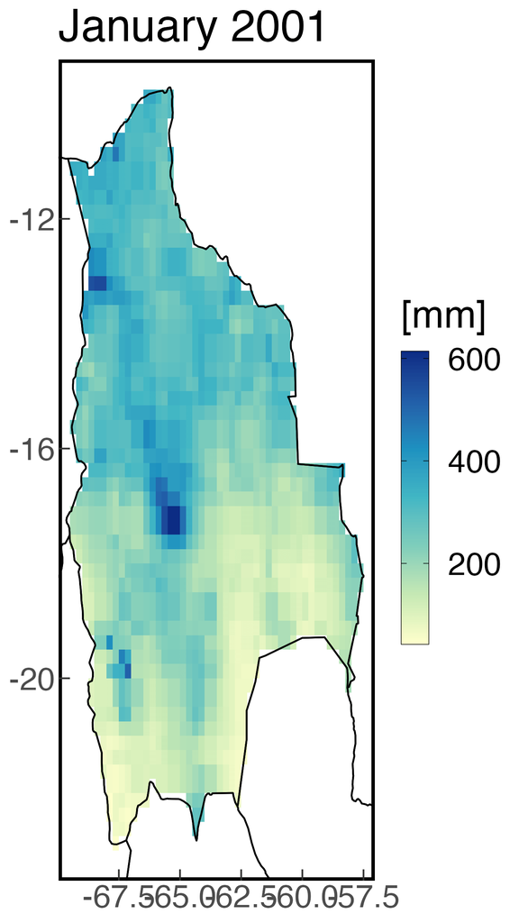

```r
plot_map(gpm_bol)
```

### Time Series Visuals

#### Line

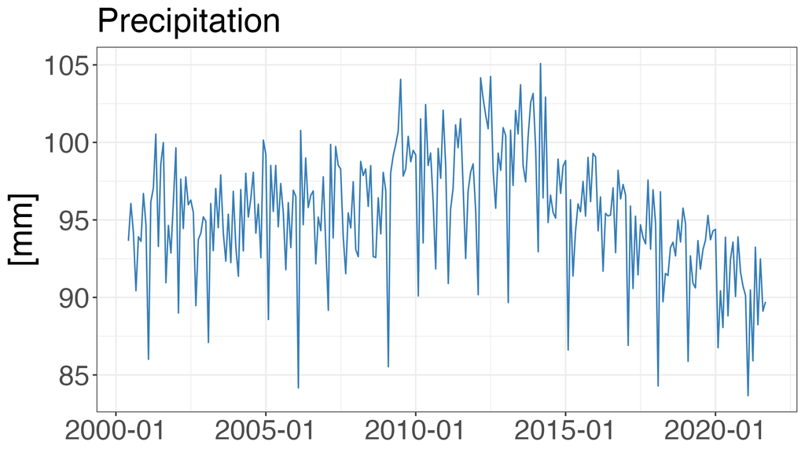

```r
plot_line(gpm_global_ts)
```

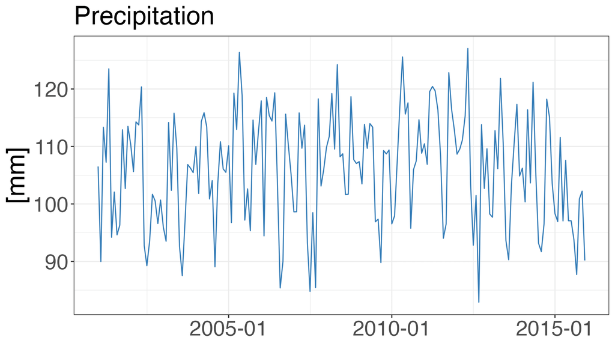

```r
plot_line(gpm_subset_ts)
```

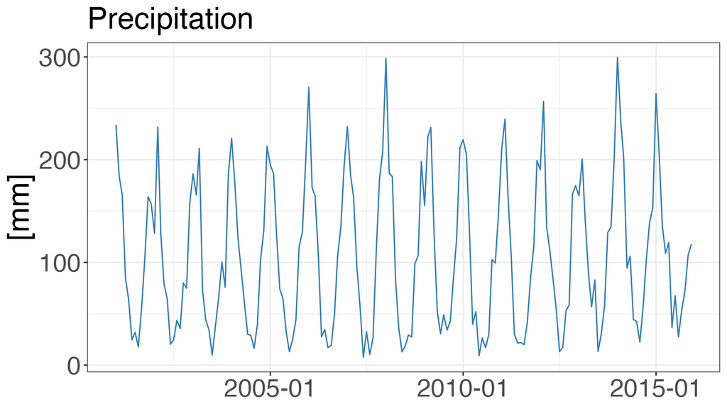

```r
plot_line(gpm_bol_ts)
```

#### Heatmap

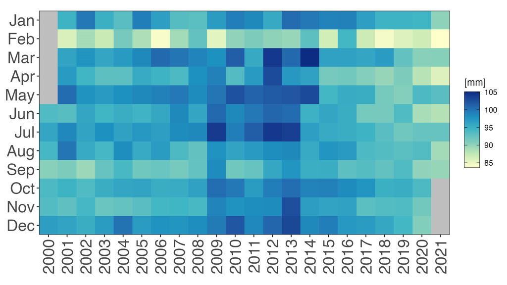

```r
plot_heatmap(gpm_global_ts)
```

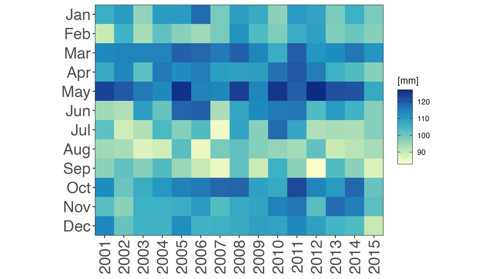

```r
plot_heatmap(gpm_subset_ts)
```

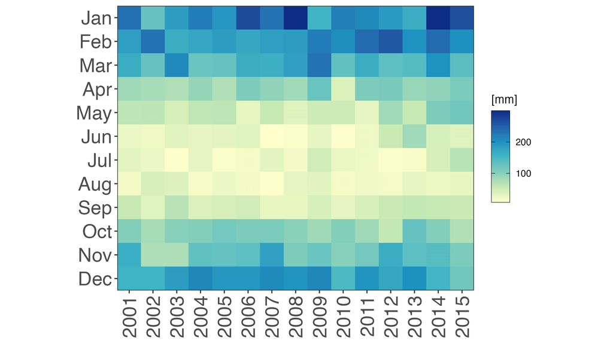

```r
plot_heatmap(gpm_bol_ts)
```

#### Boxplot

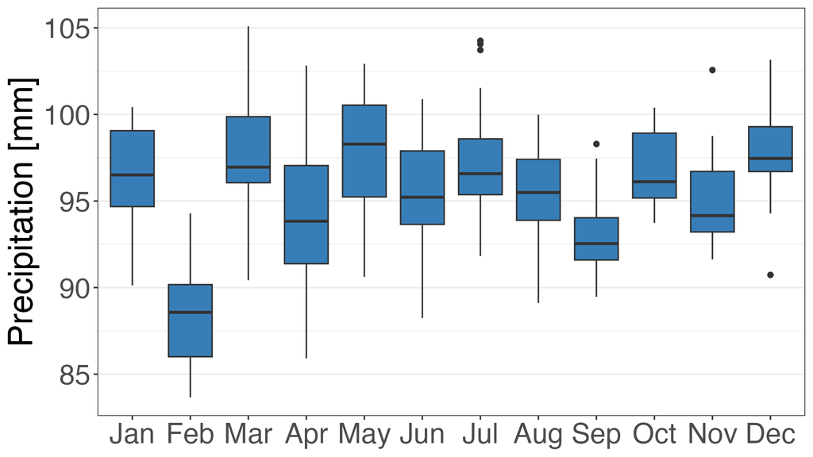

```r
plot_box(gpm_global_ts)
```

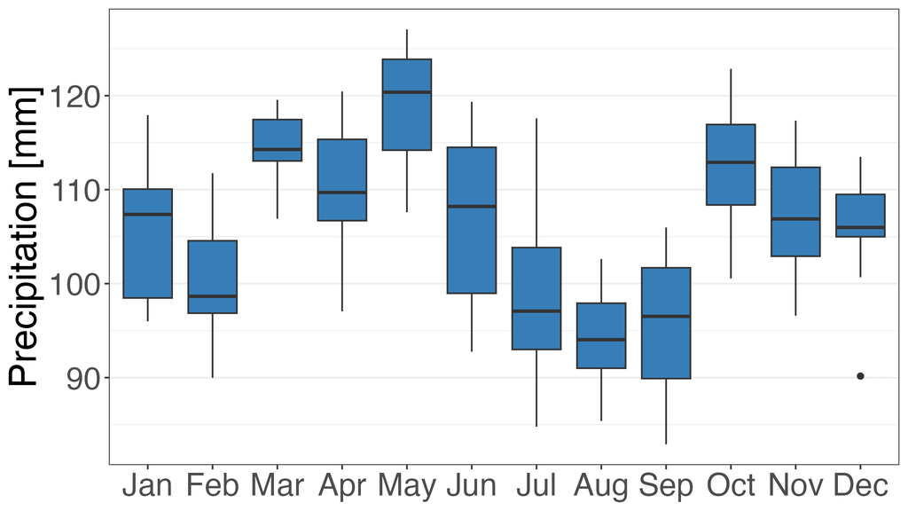

```r
plot_box(gpm_subset_ts)
```

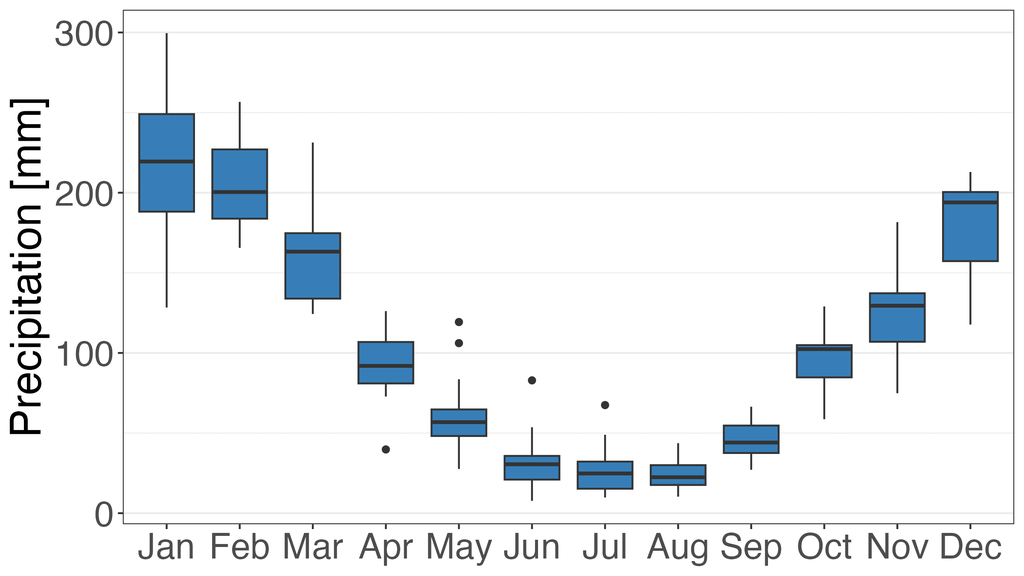

```r
plot_box(gpm_bol_ts)
```

#### Density

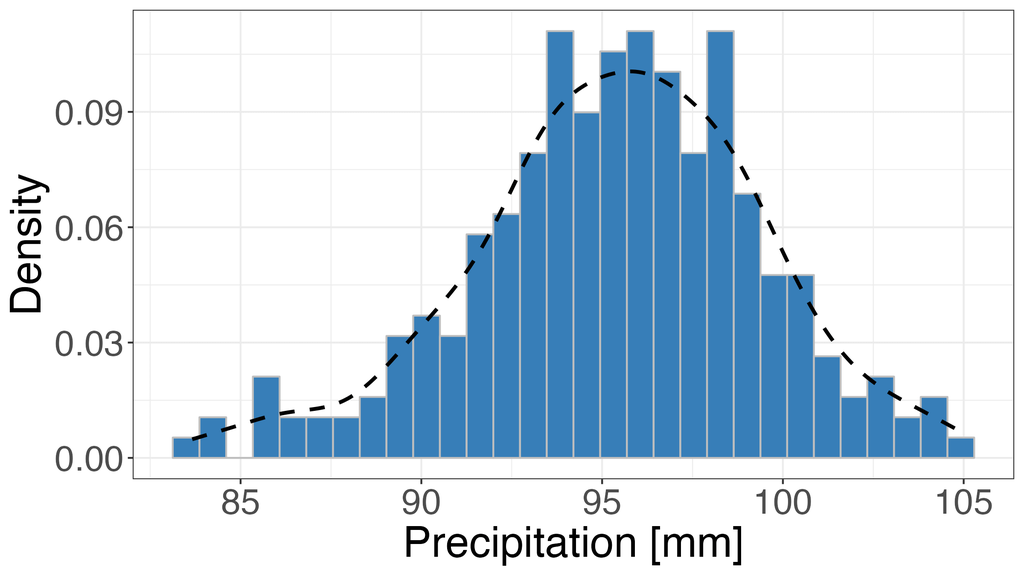

```r
plot_density(gpm_global_ts)
```

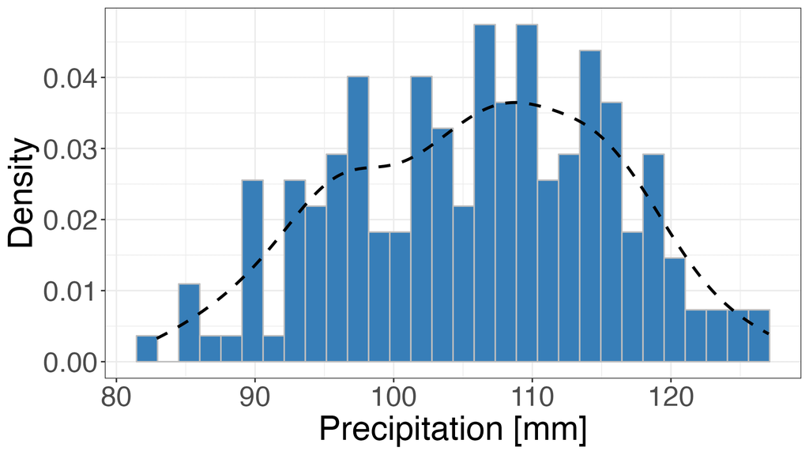

```r
plot_density(gpm_subset_ts)
```

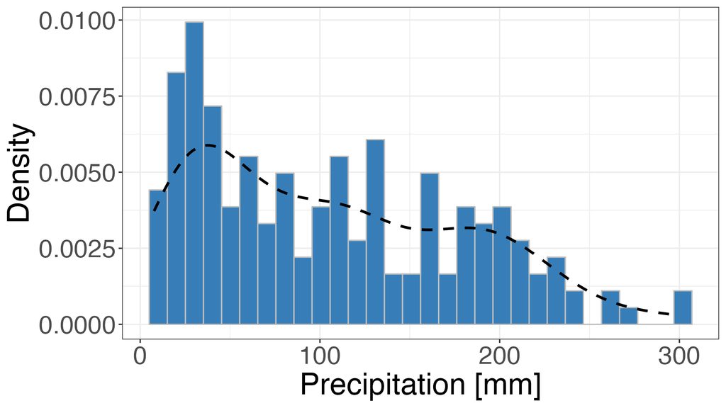

```r
plot_density(gpm_bol_ts)
```

#### Summary

**NOTE:** For good aesthetics we recommend saving `plot_summary` with `ggsave(<filename>, <plot>, width = 16, height = 13.5)`.

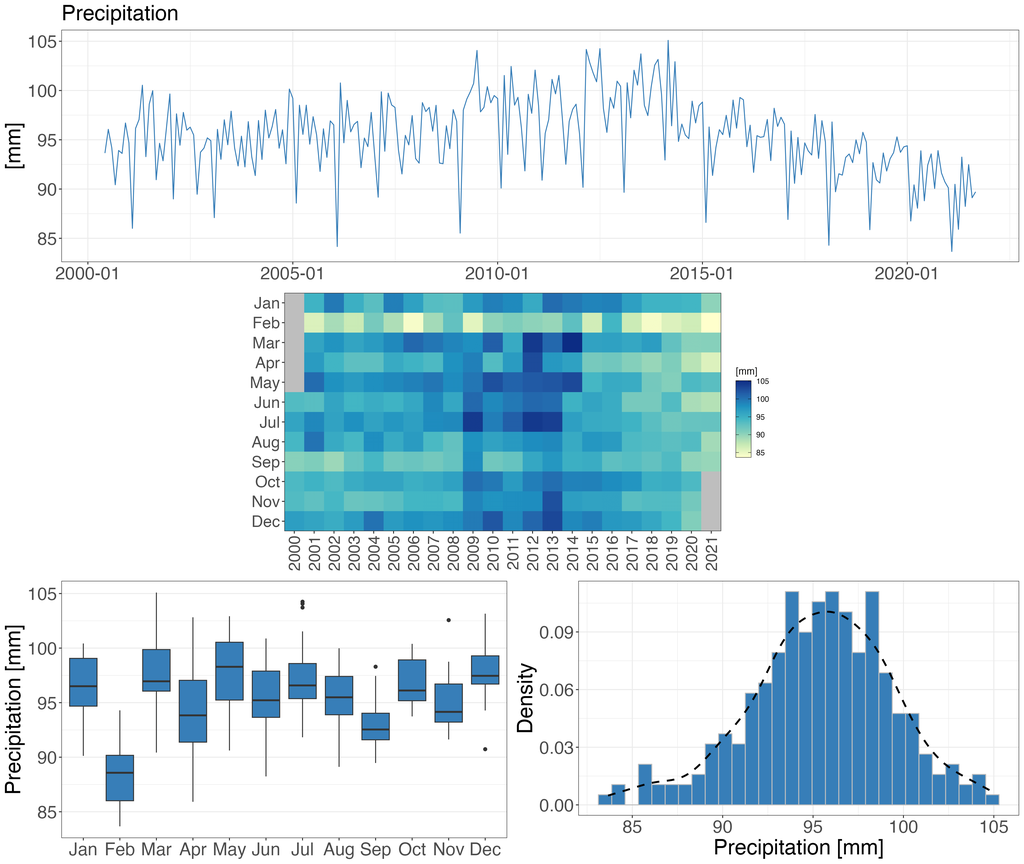

```r
plot_summary(gpm_global_ts)
#plot_summary(gpm_subset_ts)
#plot_summary(gpm_cz_ts)
```

# Coming Soon

More functions for data processing and analysis and expanding the database.

# References

Abatzoglou, John T, Solomon Z Dobrowski, Sean A Parks, and Katherine C Hegewisch. 2018. “TerraClimate, a High-Resolution Global Dataset of Monthly Climate and Climatic Water Balance from 1958–2015.” *Scientific Data* 5 (1): 1–12.

Adler, Robert F., Mathew R. P. Sapiano, George J. Huffman, Jian-Jian Wang, Guojun Gu, David Bolvin, Long Chiu, et al. 2018. “The Global Precipitation Climatology Project (GPCP) Monthly Analysis (New Version 2.3) and a Review of 2017 Global Precipitation.” *Atmosphere* 9 (4): 138. https://doi.org/10.3390/atmos9040138.

Ashouri, Hamed, Kuo-Lin Hsu, Soroosh Sorooshian, Dan K. Braithwaite, Kenneth R. Knapp, L. Dewayne Cecil, Brian R. Nelson, and Olivier P. Prat. 2015. “PERSIANN-CDR: Daily Precipitation Climate Data Record from Multisatellite Observations for Hydrological and Climate Studies.” *Bulletin of the American Meteorological Society* 96 (1): 69–83.

Beck, Hylke E, Eric F Wood, Ming Pan, Colby K Fisher, Diego G Miralles, Albert IJM Van Dijk, Tim R McVicar, and Robert F Adler. 2019. “MSWEP V2 Global 3-Hourly 0.1 Precipitation: Methodology and Quantitative Assessment.” *Bulletin of the American Meteorological Society* 100 (3): 473–500.

Chen, Mingyue, Pingping Xie, John E. Janowiak, and Phillip A. Arkin. 2002. “Global Land Precipitation: A 50-Yr Monthly Analysis Based on Gauge Observations.” *Journal of Hydrometeorology* 3 (3): 249–66.

Funk, Chris, Pete Peterson, Martin Landsfeld, Diego Pedreros, James Verdin, Shraddhanand Shukla, Gregory Husak, et al. 2015. “The Climate Hazards Infrared Precipitation with Stations—a New Environmental Record for Monitoring Extremes.” *Scientific Data* 2 (1): 150066. https://doi.org/10.1038/sdata.2015.66.

Gelaro, Ronald, Will McCarty, Max J. Suárez, Ricardo Todling, Andrea Molod, Lawrence Takacs, Cynthia A. Randles, et al. 2017. “The Modern-Era Retrospective Analysis for Research and Applications, Version 2 (MERRA-2).” *Journal of Climate* 30 (14): 5419–54. https://doi.org/10.1175/JCLI-D-16-0758.1.

Harris, Ian, Timothy J Osborn, Phil Jones, and David Lister. 2020. “Version 4 of the CRU TS Monthly High-Resolution Gridded Multivariate Climate Dataset.” *Scientific Data* 7 (1): 1–18.

Hersbach, Hans, Bill Bell, Paul Berrisford, Shoji Hirahara, András Horányi, Joaquín Muñoz-Sabater, Julien Nicolas, et al. 2020. “The ERA5 Global Reanalysis.” *Quarterly Journal of the Royal Meteorological Society* 146 (730): 1999–2049.

Huffman, G. J., E. F. Stocker, D. T. Bolvin, E. J. Nelkin, and Jackson Tan. 2019. *GPM IMERG Final Precipitation L3 1 Month 0.1 Degree x 0.1 Degree V06, Greenbelt, MD, Goddard Earth Sciences Data and Information Services Center (GES DISC)*.

Huffman, George J, Robert F Adler, David T Bolvin, and Eric J Nelkin. 2010. “The TRMM Multi-Satellite Precipitation Analysis (TMPA).” In *Satellite Rainfall Applications for Surface Hydrology*, 3–22. Springer.

Joyce, Robert J, John E Janowiak, Phillip A Arkin, and Pingping Xie. 2004. “CMORPH: A Method That Produces Global Precipitation Estimates from Passive Microwave and Infrared Data at High Spatial and Temporal Resolution.” *Journal of Hydrometeorology* 5 (3): 487–503.

Kalnay, Eugenia, Masao Kanamitsu, Robert Kistler, William Collins, Dennis Deaven, Lev Gandin, Mark Iredell, Suranjana Saha, Glenn White, and John Woollen. 1996. “The NCEP/NCAR 40-Year Reanalysis Project.” *Bulletin of the American Meteorological Society* 77 (3): 437–72.

Kanamitsu, Masao, Wesley Ebisuzaki, Jack Woollen, Shi-Keng Yang, J. J. Hnilo, M. Fiorino, and G. L. Potter. 2002. “Ncep–Doe Amip-Ii Reanalysis (r-2).” *Bulletin of the American Meteorological Society* 83 (11): 1631–44.

Kobayashi, Shinya, Yukinari Ota, Yayoi Harada, Ayataka Ebita, Masami Moriya, Hirokatsu Onoda, Kazutoshi Onogi, et al. 2015. “The JRA-55 Reanalysis: General Specifications and Basic Characteristics.” *Journal of the Meteorological Society of Japan. Ser. II* 93 (1): 5–48. https://doi.org/10.2151/jmsj.2015-001.

McNally, Amy, Kristi Arsenault, Sujay Kumar, Shraddhanand Shukla, Pete Peterson, Shugong Wang, Chris Funk, Christa D. Peters-Lidard, and James P. Verdin. 2017. “A Land Data Assimilation System for Sub-Saharan Africa Food and Water Security Applications.” *Scientific Data* 4 (1): 170012. https://doi.org/10.1038/sdata.2017.12.

Peterson, Thomas C., and Russell S. Vose. 1997. “An Overview of the Global Historical Climatology Network Temperature Database.” *Bulletin of the American Meteorological Society* 78 (12): 2837–50.

Poli, Paul, Hans Hersbach, Dick P Dee, Paul Berrisford, Adrian J Simmons, Frédéric Vitart, Patrick Laloyaux, et al. 2016. “ERA-20C: An Atmospheric Reanalysis of the Twentieth Century.” *Journal of Climate* 29 (11): 4083–97.

Rodell, Matthew, P. R. Houser, U. E. A. Jambor, J. Gottschalck, K. Mitchell, C.-J. Meng, K. Arsenault, B. Cosgrove, J. Radakovich, and M. Bosilovich. 2004. “The Global Land Data Assimilation System.” *Bulletin of the American Meteorological Society* 85 (3): 381–94.

Schneider, Udo, Andreas Becker, Peter Finger, Anja Meyer-Christoffer, Bruno Rudolf, and Markus Ziese. 2011. “GPCC Full Data Reanalysis Version 6.0 at 0.5: Monthly Land-Surface Precipitation from Rain-Gauges Built on GTS-Based and Historic Data.” *GPCC Data Rep., Doi* 10.

Slivinski, Laura C, Gilbert P Compo, Jeffrey S Whitaker, Prashant D Sardeshmukh, Benjamin S Giese, Chesley McColl, Rob Allan, et al. 2019. “Towards a More Reliable Historical Reanalysis: Improvements for Version 3 of the Twentieth Century Reanalysis System.” *Quarterly Journal of the Royal Meteorological Society* 145 (724): 2876–2908.

Tang, Guoqiang, Martyn P. Clark, and Simon Michael Papalexiou. 2022. “EM-Earth: The Ensemble Meteorological Dataset for Planet Earth.” *Bulletin of the American Meteorological Society* 103 (4): E996–1018. https://doi.org/10.1175/BAMS-D-21-0106.1.

Vargas Godoy, Mijael Rodrigo, and Yannis Markonis. 2023. “pRecipe: A Global Precipitation Climatology Toolbox and Database.” *Environmental Modelling & Software* 165: 105711.

Vargas Godoy, Mijael Rodrigo, Yannis Markonis, Martin Hanel, Jan Kyselỳ, and Simon Michael Papalexiou. 2021. “The Global Water Cycle Budget: A Chronological Review.” *Surveys in Geophysics* 42 (5): 1075–1107.

Willmott, C. J., and K. Matsuura. 2001. *Terrestrial Air Temperature and Precipitation: Monthly and Annual Time Series (1950 - 1999)*.

Xie, P., M. Chen, and W. Shi. 2010. “CPC Global Unified Gauge-Based Analysis of Daily Precipitation.” In *Preprints, 24th Conf. On Hydrology, Atlanta, GA, Amer. Metero. Soc*. Vol. 2.

Xie, Pingping, and Phillip A. Arkin. 1997. “Global Precipitation: A 17-Year Monthly Analysis Based on Gauge Observations, Satellite Estimates, and Numerical Model Outputs.” *Bulletin of the American Meteorological Society* 78 (11): 2539–58.